# Project 1

Farid Saud

**STAT 542** Statistical Learning

### Libraries & Packages:

```r
knitr::opts_chunk$set(echo = TRUE,fig.align='center')

library(knitr)
library(class)

# Progress bar
library(progress)

#For the plots:
library(ggplot2)
library(caret)
library(tidyr)
library(viridis)
# regularization models
library(glmnet)
# tree based models
library(randomForest)
library(xgboost)
```

## **Part I: Loading and Pre-processing training data**

### 1.1. Loading the data:

The training data for this project is stored in 10 separate “folds”, and these datasets contain the features and response variables.

```r
for (fold_number in 1:10) {

  # Construct the path to the files for this fold
  fold_folder <- file.path("./proj1", paste0("fold", fold_number))

  # Read the training data
  train_path <- file.path(fold_folder, "train.csv")
  assign(paste0("train_", fold_number), read.csv(train_path, header = TRUE))

}
```

To show how these datasets look like, the first, fourth and seventh `train.csv` datasets are displayed:

```r
cat("train_1: ",dim(train_1))
```

```
## train_1:  2051 83
```

```r
cat("\ntrain_4: ",dim(train_4))
```

```
##
## train_4:  2051 83
```

```r
cat("\ntrain_7: ",dim(train_7))
```

```
##
## train_7:  2051 83
```

There are 2051 observations in each of the datasets. The 83 columns correspond to 82 features (numerical and categorical variables), plus the response variable **Y**, `Sale_Price`.

### 1.2. NA observations:

Prior to any analysis of the variables and transformations, if any is needed, it is critical to deal with missing values, if any. In this project, any incomplete observation is handled by transforming the “NA” into “0”. By doing so, removing observations is avoided.

```r
cat("train_1: ")
```

```
## train_1:
```

```r
table(complete.cases(train_1))
```

```
##
## FALSE  TRUE
##   108  1943
```

```r
cat("\ntrain_4: ")
```

```
##
## train_4:
```

```r
table(complete.cases(train_4))
```

```
##
## FALSE  TRUE
##   110  1941
```

```r
cat("\ntrain_7: ")
```

```
##
## train_7:
```

```r
table(complete.cases(train_7))
```

```
##
## FALSE  TRUE
##   108  1943
```

Double checking for `is.na` observations:

```r
length(train_1[is.na(train_1)])
```

```
## [1] 108
```

The following loop transforms any `NA` into 0, in the 10 train dataframes:

```r
for (fold_number in 1:10) {

  # Handle NAs for train_ data
  train_data <- get(paste0("train_", fold_number))
  train_data[is.na(train_data)] <- 0
  assign(paste0("train_", fold_number), train_data)

}
```

### 1.3. Feature matrix X, Response vector Y, and Transformations:

As mentioned earlier, the train dataframes contain 82 features and the response variable. It may be more convenient to have the response variable stored separately. In this step, `Sale_Price` is transformed into log(`Sale_Price`) before assigning it to the new object for the response variable, **Y_train_**:

```r
for (fold_number in 1:10) {

  # Extract the data for each fold
  train_data <- get(paste0("train_", fold_number))

  # Assign transformed data back
  assign(paste0("X.train_", fold_number), subset(train_data, select = -Sale_Price))

  # Assign the log-transformed Sale_Price to a new variable
  assign(paste0("Y.train_", fold_number), log(train_data$Sale_Price))
}
```

The resulting matrices **X_train_** and vectors **Y_train_** have the following dimensions:

```r
cat("X.train_1: ",dim(X.train_1))
```

```
## X.train_1:  2051 82
```

```r
cat("\nY.train_1: ",length(Y.train_1))
```

```
##
## Y.train_1:  2051
```

In all of the 10 feature matrices X_train, the variables are of the types:

```r
type.counts <- table(sapply(X.train_1, class))
type.counts
```

```
##
## character   integer   numeric
##        46        33         3
```

, and these correspond to:

```r
split(names(X.train_1), sapply(X.train_1, class))
```

```
## $character
##  [1] "MS_SubClass"    "MS_Zoning"      "Street"         "Alley"
##  [5] "Lot_Shape"      "Land_Contour"   "Utilities"      "Lot_Config"
##  [9] "Land_Slope"     "Neighborhood"   "Condition_1"    "Condition_2"
## [13] "Bldg_Type"      "House_Style"    "Overall_Qual"   "Overall_Cond"
## [17] "Roof_Style"     "Roof_Matl"      "Exterior_1st"   "Exterior_2nd"
## [21] "Mas_Vnr_Type"   "Exter_Qual"     "Exter_Cond"     "Foundation"
## [25] "Bsmt_Qual"      "Bsmt_Cond"      "Bsmt_Exposure"  "BsmtFin_Type_1"
## [29] "BsmtFin_Type_2" "Heating"        "Heating_QC"     "Central_Air"
## [33] "Electrical"     "Kitchen_Qual"   "Functional"     "Fireplace_Qu"
## [37] "Garage_Type"    "Garage_Finish"  "Garage_Qual"    "Garage_Cond"
## [41] "Paved_Drive"    "Pool_QC"        "Fence"          "Misc_Feature"
## [45] "Sale_Type"      "Sale_Condition"
##
## $integer
##  [1] "PID"                "Lot_Frontage"       "Lot_Area"
##  [4] "Year_Built"         "Year_Remod_Add"     "Mas_Vnr_Area"
##  [7] "BsmtFin_SF_1"       "BsmtFin_SF_2"       "Bsmt_Unf_SF"
## [10] "Total_Bsmt_SF"      "First_Flr_SF"       "Second_Flr_SF"
## [13] "Low_Qual_Fin_SF"    "Gr_Liv_Area"        "Bsmt_Full_Bath"
## [16] "Bsmt_Half_Bath"     "Full_Bath"          "Half_Bath"
## [19] "Bedroom_AbvGr"      "Kitchen_AbvGr"      "TotRms_AbvGrd"
## [22] "Fireplaces"         "Garage_Cars"        "Garage_Area"
## [25] "Wood_Deck_SF"       "Open_Porch_SF"      "Enclosed_Porch"
## [28] "Three_season_porch" "Screen_Porch"       "Pool_Area"
## [31] "Misc_Val"           "Mo_Sold"            "Year_Sold"
##
## $numeric
## [1] "Garage_Yr_Blt" "Longitude"     "Latitude"
```

The character `character`, as well as the “Latitude” and “Longitude” variables will be treated as categorical variables. The rest of the variables will be treated as numerical variables.

### 1.4. Categorical Variables

#### 1.4.1. Unbalanced categorical variables

- Street
- Utilities
- Condition_2
- Roof_Matl
- Heating
- Pool_QC
- Misc_Feature
- Low_Qual_Fin_SF
- Pool_Area

To illustrate this, `Street`, `Utilities` and `Roof_Matl` categories counts and barplots are presented below:

```r
# Table
table_street <- table(X.train_4$Street)
print(table_street)
```

```
##
## Grvl Pave
##    9 2042
```

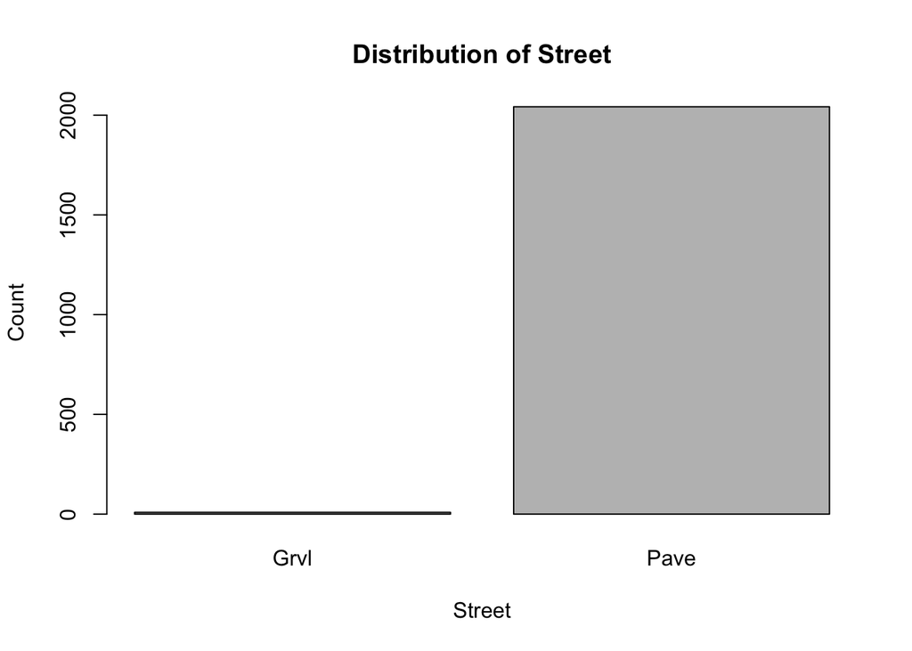

```r
# Barplot
barplot(table_street, main="Distribution of Street", xlab="Street", ylab="Count")
```

```r
# Table
table_utilities <- table(X.train_4$Utilities)
print(table_utilities)
```

```
##
## AllPub NoSewr
##   2049      2
```

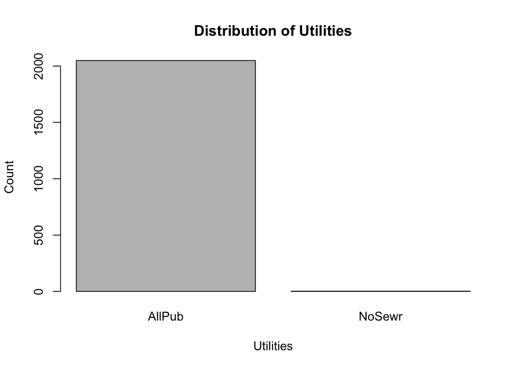

```r
# Barplot
barplot(table_utilities, main="Distribution of Utilities", xlab="Utilities", ylab="Count")
```

```r
# Table
table_roof_matl <- table(X.train_4$Roof_Matl)
print(table_roof_matl)
```

```
##
## CompShg Membran   Metal Tar&Grv WdShake WdShngl
##    2016       1       1      18       8       7
```

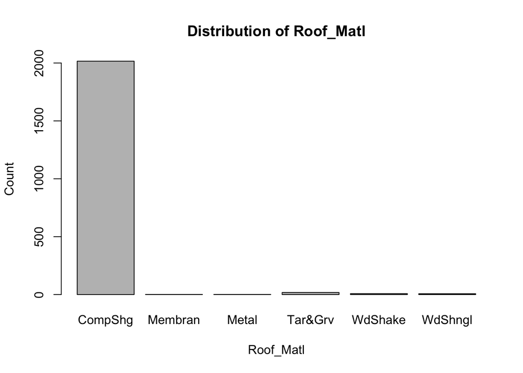

```r
# Barplot
barplot(table_roof_matl, main="Distribution of Roof_Matl", xlab="Roof_Matl", ylab="Count")
```

These extremely unbalanced categorical variables would affect the predictive power of any models to be trained later. It was determined that these, alongside `latitude` and `longitude` are to be removed:

```r
# List of columns to remove
columns_to_remove <- c('Street', 'Utilities', 'Condition_2', 'Roof_Matl', 'Heating',
                       'Pool_QC', 'Misc_Feature', 'Low_Qual_Fin_SF', 'Pool_Area',
                       'Longitude', 'Latitude')

for (fold_number in 1:10) {

  # Extract the train data for this fold
  train_data <- get(paste0("X.train_", fold_number))

  # Remove the columns
  train_data <- train_data[, !(names(train_data) %in% columns_to_remove)]

  # Assign the modified data back
  assign(paste0("X.train_", fold_number), train_data)
}
```

#### 1.4.2. Variable Encoding

The models to be trained in this analysis need to have the categorical variables enconded. For this, it was determined that the best way to handle this is by **One-hot encoding**. For each X.train_ dataframe, the categorical variables are encoded as follows:

```r
train_columns_list <- list()

for (fold_number in 1:10) {

  # Extract the train data for this fold
  train_data <- get(paste0("X.train_", fold_number))

  ## One-Hot Encoding of Categorical Variables
  categorical.vars = colnames(train_data)[which(sapply(train_data, function(x) mode(x) == "character"))]
  train.matrix = as.data.frame(train_data[, !colnames(train_data) %in% categorical.vars, drop = FALSE])
  n.train = nrow(train.matrix)
  for(var in categorical.vars) {
    mylevels = sort(unique(train_data[, var]))
    m = length(mylevels)
    m = ifelse(m > 2, m, 1)
    tmp.train = matrix(0, n.train, m)
    col.names = NULL
    for(j in 1:m) {
      tmp.train[train_data[, var] == mylevels[j], j] = 1
      col.names = c(col.names, paste(var, '_', mylevels[j], sep = ''))
    }
    colnames(tmp.train) = col.names
    train.matrix = cbind(train.matrix, tmp.train)
  }
  train_data = train.matrix

  # Assign the modified data back
  assign(paste0("X.train_", fold_number), train_data)

  # Store column names of the transformed dataset in the list
  train_columns_list[[fold_number]] <- colnames(train_data)
}
```

For consistency when working with the test datasets, the names of the columns kept are stored in the `train_columns_list` list.

### 1.5. Numerical Variables

#### 1.5.1. Winsorization

It was suggested that the impact of some area-related variables should have a ceiling. For this analysis, the following 16 variables:

- Lot_Frontage
- Lot_Area
- Mas_Vnr_Area
- BsmtFin_SF_2
- Bsmt_Unf_SF
- Total_Bsmt_SF
- Second_Flr_SF
- First_Flr_SF
- Gr_Liv_Area
- Garage_Area
- Wood_Deck_SF
- Open_Porch_SF
- Enclosed_Porch
- Three_season_porch
- Screen_Porch
- Misc_Val

, are capped at the corresponding 95% upper quantile:

```r
variables_to_winsorize <- c("Lot_Frontage", "Lot_Area", "Mas_Vnr_Area", "BsmtFin_SF_2",
                            "Bsmt_Unf_SF", "Total_Bsmt_SF", "Second_Flr_SF", "First_Flr_SF",
                            "Gr_Liv_Area", "Garage_Area", "Wood_Deck_SF", "Open_Porch_SF",
                            "Enclosed_Porch", "Three_season_porch", "Screen_Porch", "Misc_Val")

for (fold_number in 1:10) {

  # Extract the train data for this fold
  train_data <- get(paste0("X.train_", fold_number))

  ## Winsorization
  upper_bounds_list <- list()
  for (var in variables_to_winsorize) {

    # Check if the variable exists in the dataset
    if (var %in% colnames(train_data)) {
      upper_bound <- quantile(train_data[[var]], 0.95, na.rm = TRUE)
      upper_bounds_list[[var]] <- upper_bound
      train_data[[var]][train_data[[var]] > upper_bound] <- upper_bound
    }
  }

  # Assign the modified data back
  assign(paste0("X.train_", fold_number), train_data)

  # Store upper bounds for this fold (optional)
  assign(paste0("upper_bounds_", fold_number), upper_bounds_list)
}
```

For consistency when working with the test datasets, the upper bounds of the winsorized numerical variables are stored in the `upper_bounds_` lists.

```r
(str(upper_bounds_1))
```

```
## List of 16
##  $ Lot_Frontage      : Named num 104
##   ..- attr(*, "names")= chr "95%"
##  $ Lot_Area          : Named num 16972
##   ..- attr(*, "names")= chr "95%"
##  $ Mas_Vnr_Area      : Named num 472
##   ..- attr(*, "names")= chr "95%"
##  $ BsmtFin_SF_2      : Named num 445
##   ..- attr(*, "names")= chr "95%"
##  $ Bsmt_Unf_SF       : Named num 1452
##   ..- attr(*, "names")= chr "95%"
##  $ Total_Bsmt_SF     : Named num 1756
##   ..- attr(*, "names")= chr "95%"
##  $ Second_Flr_SF     : Named num 1130
##   ..- attr(*, "names")= chr "95%"
##  $ First_Flr_SF      : Named num 1814
##   ..- attr(*, "names")= chr "95%"
##  $ Gr_Liv_Area       : Named num 2466
##   ..- attr(*, "names")= chr "95%"
##  $ Garage_Area       : Named num 852
##   ..- attr(*, "names")= chr "95%"
##  $ Wood_Deck_SF      : Named num 324
##   ..- attr(*, "names")= chr "95%"
##  $ Open_Porch_SF     : Named num 179
##   ..- attr(*, "names")= chr "95%"
##  $ Enclosed_Porch    : Named num 174
##   ..- attr(*, "names")= chr "95%"
##  $ Three_season_porch: Named num 0
##   ..- attr(*, "names")= chr "95%"
##  $ Screen_Porch      : Named num 168
##   ..- attr(*, "names")= chr "95%"
##  $ Misc_Val          : Named num 0
##   ..- attr(*, "names")= chr "95%"
```

## **Part II: Predictive Models**

### 2.1. Regularizatin model:

#### **Ridge, Lasso & Elastic Nets**

```r
elastic_net_training <- function(fold_number, alfa) {

  # Extract the train data for this fold
  train_ <- get(paste0("X.train_", fold_number))
  Y_train <- get(paste0("Y.train_", fold_number))


  # glmnet training:
  ## X: Matrix
  X = data.matrix(train_)
  ## Y: Vector
  Y = Y_train

  ## Model
  cv.out = cv.glmnet(X, Y, alpha = alfa)  # Cross Validation for Lambda
}
```

This function’s output is an elastic net model fitted using “X.train_” and “Y.train_” from a fold. The function receives the `fold_number` as an input to be able to fit a model for any of the folds. It also receives the `alpha` parameter as an input, which allows for quick comparison between different elastic nets.

This is how a model can be fit for a specific fold and alpha parameter:

```r
m1 <- elastic_net_training(1,0.5)
m1
```

```
##
## Call:  cv.glmnet(x = X, y = Y, alpha = alfa)
##
## Measure: Mean-Squared Error
##
##       Lambda Index Measure       SE Nonzero
## min 0.005261    52 0.01556 0.001482     127
## 1se 0.013339    42 0.01675 0.001711      84
```

```r
summary(m1)
```

```
##            Length Class  Mode
## lambda     86     -none- numeric
## cvm        86     -none- numeric
## cvsd       86     -none- numeric
## cvup       86     -none- numeric
## cvlo       86     -none- numeric
## nzero      86     -none- numeric
## call        4     -none- call
## name        1     -none- character
## glmnet.fit 12     elnet  list
## lambda.min  1     -none- numeric
## lambda.1se  1     -none- numeric
## index       2     -none- numeric
```

## **Part III: Loading and pre-processing testing data**

### 3.1. Loading the data:

Just like it was done for the training data, the test data has to be read and processed. This test data has a slightly different format, as the features and response variable are already separated into 2 different files. Considering this, the data is loaded as follows:

```r
for (fold_number in 1:10) {

  # Construct the path to the files for this fold
  fold_folder <- file.path("./proj1", paste0("fold", fold_number))

  # Read the test data
  test_path <- file.path(fold_folder, "test.csv")
  assign(paste0("X.test_", fold_number), read.csv(test_path, header = TRUE))

  # Read the test_y data
  test_y_path <- file.path(fold_folder, "test_y.csv")
  Y.test <- read.csv(test_y_path, header = TRUE)
  assign(paste0("Y.test_", fold_number), Y.test$Sale_Price)
}
```

The resulting matrices **X.test_** and vectors **Y.test_** have the following dimensions:

```r
cat("X.test_1: ",dim(X.test_1))
```

```
## X.test_1:  879 82
```

```r
cat("\nY.test_1: ",length(Y.test_1))
```

```
##
## Y.test_1:  879
```

### 3.2. Pre-processing:

For consistency (and so that the predictive models work correctly), the same processing steps are taken for the test data.

**NA observations**

In this project, the incomplete observations are handled by transforming the “NA” into “0”:

```r
table(complete.cases(X.test_1))
```

```
##
## FALSE  TRUE
##    51   828
```

```r
table(complete.cases(Y.test_1))
```

```
##
## TRUE
##  879
```

If any:

```r
for (fold_number in 1:10) {

  # Handle NAs for X.test_ data
  test_data <- get(paste0("X.test_", fold_number))
  test_data[is.na(test_data)] <- 0
  assign(paste0("X.test_", fold_number), test_data)

  # Handle NAs for Y.test_ data
  y_test_data <- get(paste0("Y.test_", fold_number))
  y_test_data[is.na(y_test_data)] <- 0
  assign(paste0("Y.test_", fold_number), y_test_data)
}
```

After this process, there are no incomplete cases in the test datasets:

```r
table(complete.cases(X.test_7))
```

```
##
## TRUE
##  879
```

**Categorical Variables**

The categorical variables of the test datasets have to match those in the train datasets. For this, the unbalanced categorical variables removed in the pre-processing of the training datasets:

```r
columns_to_remove
```

```
##  [1] "Street"          "Utilities"       "Condition_2"     "Roof_Matl"
##  [5] "Heating"         "Pool_QC"         "Misc_Feature"    "Low_Qual_Fin_SF"
##  [9] "Pool_Area"       "Longitude"       "Latitude"
```

, are removed from the test datasets as well:

```r
for (fold_number in 1:10) {

  # Extract the train data for this fold
  test.data <- get(paste0("X.test_", fold_number))

  # Remove the columns
  test.data <- test.data[, !(names(test.data) %in% columns_to_remove)]

  # Assign the modified data back
  assign(paste0("X.test_", fold_number), test.data)
}
```

The remaining categorical variables have to be one-hot encoded, and the columns have to match those in the training datasets. For this, if there are any missing variables, such variables are added as columns with 0 as entries, and if there are any extra variables, these are removed:

```r
for (fold_number in 1:10) {

  # Extract the test data for this fold
  test_data <- get(paste0("X.test_", fold_number))

  ## One-Hot Encoding of Categorical Variables
  categorical.vars = colnames(test_data)[which(sapply(test_data, function(x) mode(x) == "character"))]
  test.matrix = as.data.frame(test_data[, !colnames(test_data) %in% categorical.vars, drop = FALSE])
  n.test = nrow(test.matrix)
  for(var in categorical.vars) {
    mylevels = sort(unique(test_data[, var]))
    m = length(mylevels)
    m = ifelse(m > 2, m, 1)
    tmp.test = matrix(0, n.test, m)
    col.names = NULL
    for(j in 1:m) {
      tmp.test[test_data[, var] == mylevels[j], j] = 1
      col.names = c(col.names, paste(var, '_', mylevels[j], sep = ''))
    }
    colnames(tmp.test) = col.names
    test.matrix = cbind(test.matrix, tmp.test)
  }
  test_data = test.matrix

  # Make sure that the test dataset has the same columns as the train dataset for this fold
  missing_columns <- setdiff(train_columns_list[[fold_number]], colnames(test_data))
  extra_columns <- setdiff(colnames(test_data), train_columns_list[[fold_number]])
  for(missing_col in missing_columns) {
    test_data[[missing_col]] <- 0
  }
  test_data <- test_data[, train_columns_list[[fold_number]], drop = FALSE]

  # Assign the modified data back
  assign(paste0("X.test_", fold_number), test_data)
}
```

**Numerical Variables**

The numerical variables are winsorized in the test datasets:

```r
for (fold_number in 1:10) {

  # Extract the test data for this fold
  test_data <- get(paste0("X.test_", fold_number))

  # Get the upper bounds from the training set
  upper_bounds_list <- get(paste0("upper_bounds_", fold_number))

  ## Winsorization using the upper bounds from the training set
  for (var in variables_to_winsorize) {

    # Check if the variable exists in the dataset
    if (var %in% colnames(test_data) && !is.null(upper_bounds_list[[var]])) {
      upper_bound <- upper_bounds_list[[var]]
      test_data[[var]][test_data[[var]] > upper_bound] <- upper_bound
    }
  }

  # Assign the modified data back
  assign(paste0("X.test_", fold_number), test_data)
}
```

## **Part IV: Predictions and Results**

### 4.1. Regularization

This section presents the predictions and results for the regularization models fitted using glmnet. Lasso, Ridge and Elastic Net regression models are included:

**Predictions**

```r
# Create a dataframe to store RMSE for each fold and alpha
RMSE.elastic <- data.frame(matrix(NA, nrow=length(seq(0, 1, by=0.1)), ncol=10))
colnames(RMSE.elastic) <- paste0("fold_", 1:10)
rownames(RMSE.elastic) <- seq(0, 1, by=0.1)

# Create a list to store predictions for each fold and alpha
predictions.elastic <- list()

# Progress
pb <- progress_bar$new(total = 10, format = "[:bar] :percent :eta", clear = FALSE)

# Loop over fold numbers
for (fold_number in 1:10) {

  # Loop over alpha values
  for (alfa in seq(0, 1, by=0.1)) {

    # Train the model using the function
    cv.model <- elastic_net_training(fold_number, alfa)

    # Predict on the test data for this fold
    test_ <- get(paste0("X.test_", fold_number))
    X_test = data.matrix(test_)
    predictions = predict(cv.model, newx = X_test, s = cv.model$lambda.min)

    # Compute RMSE
    actual_values <- log(get(paste0("Y.test_", fold_number)))
    rmse <- sqrt(mean((predictions[, 1] - actual_values)^2))

    # Store the RMSE in the dataframe
    RMSE.elastic[as.character(alfa), paste0("fold_", fold_number)] <- rmse

    # Store the predictions (optional, based on your previous code)
    predictions.elastic[[paste0("fold_", fold_number, "_alpha_", alfa)]] <- predictions

  }

  # Update the progress bar
  pb$tick()
}
```

**Results: RMSE**

```r
RMSE.elastic
```

```
##        fold_1    fold_2    fold_3    fold_4    fold_5    fold_6    fold_7
## 0   0.1219035 0.1212444 0.1202280 0.1230684 0.1149012 0.1358345 0.1285425
## 0.1 0.1221006 0.1181344 0.1195867 0.1197613 0.1110222 0.1334263 0.1263180
## 0.2 0.1224634 0.1181449 0.1203061 0.1196962 0.1114365 0.1334953 0.1261151
## 0.3 0.1225572 0.1176748 0.1206634 0.1199660 0.1117690 0.1334036 0.1256007
## 0.4 0.1228164 0.1177844 0.1208437 0.1198249 0.1117664 0.1332030 0.1260763
## 0.5 0.1225429 0.1175442 0.1210835 0.1198914 0.1120842 0.1327688 0.1263872
## 0.6 0.1225582 0.1173349 0.1210475 0.1200452 0.1120069 0.1328363 0.1268756
## 0.7 0.1226693 0.1180197 0.1214243 0.1223996 0.1120834 0.1330269 0.1259803
## 0.8 0.1226275 0.1177407 0.1212775 0.1206059 0.1123084 0.1327827 0.1259818
## 0.9 0.1226419 0.1175315 0.1211984 0.1217746 0.1122084 0.1330018 0.1269046
## 1   0.1226518 0.1177448 0.1216121 0.1309565 0.1123117 0.1330037 0.1263588
##        fold_8    fold_9   fold_10
## 0   0.1210423 0.1333298 0.1283753
## 0.1 0.1192231 0.1301495 0.1238121
## 0.2 0.1194546 0.1296916 0.1236496
## 0.3 0.1204933 0.1300007 0.1238589
## 0.4 0.1204610 0.1294460 0.1235443
## 0.5 0.1204451 0.1293171 0.1235392
## 0.6 0.1204357 0.1299450 0.1240649
## 0.7 0.1204331 0.1296966 0.1240580
## 0.8 0.1204450 0.1294093 0.1236014
## 0.9 0.1204395 0.1299474 0.1237935
## 1   0.1204426 0.1299523 0.1236099
```

**Results: Plots**

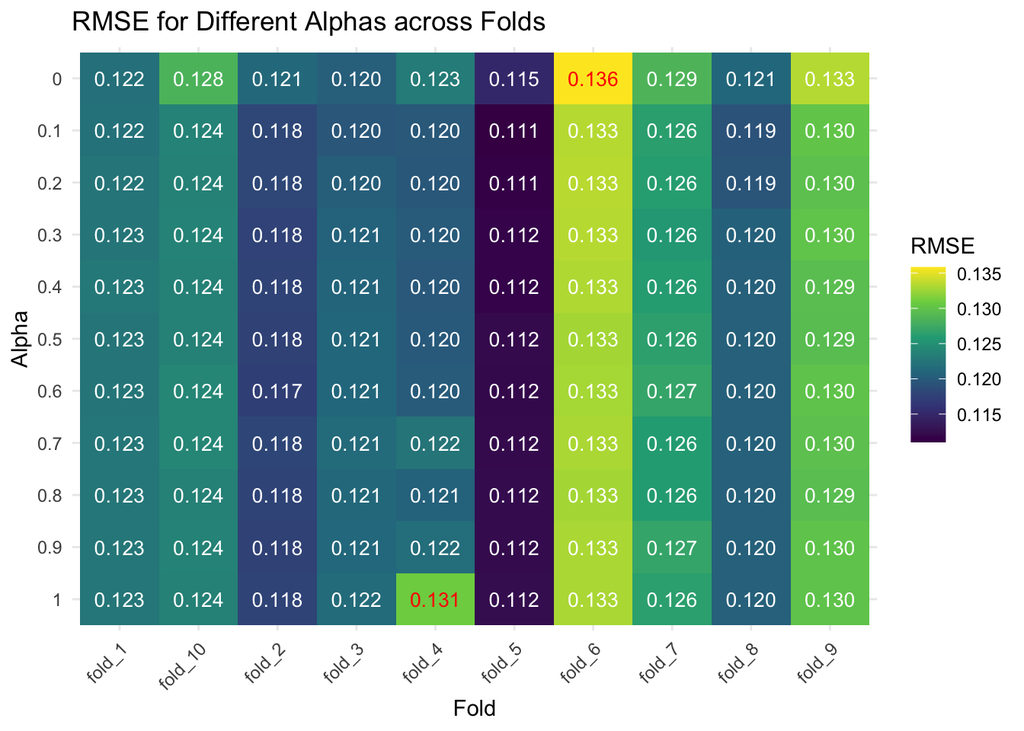

```r
# Convert the RMSE.elastic dataframe to long format for plotting
results_long <- tidyr::pivot_longer(RMSE.elastic, cols = starts_with("fold_"),
                                    names_to = "Fold", values_to = "RMSE")
results_long$Alpha <- rep(rownames(RMSE.elastic), each=10)

# Heatmap
ggplot(results_long, aes(x = Fold, y = factor(Alpha, levels = rev(unique(Alpha))), fill = RMSE)) +
  geom_tile() +
  scale_fill_viridis_c() +
  geom_text(aes(label=sprintf("%.3f", RMSE),
                color=ifelse((RMSE > 0.125 & as.numeric(gsub("fold_", "", Fold)) <= 5) |
                             (RMSE > 0.135 & as.numeric(gsub("fold_", "", Fold)) > 5), "red", "white")),
            size=3.5) +
  scale_color_identity(guide = "none") +  # This line prevents the legend for text color

  labs(title = "RMSE for Different Alphas across Folds",
       x = "Fold", y = "Alpha", fill = "RMSE") +
  theme_minimal() +
  theme(axis.text.x = element_text(angle = 45, hjust = 1))
```

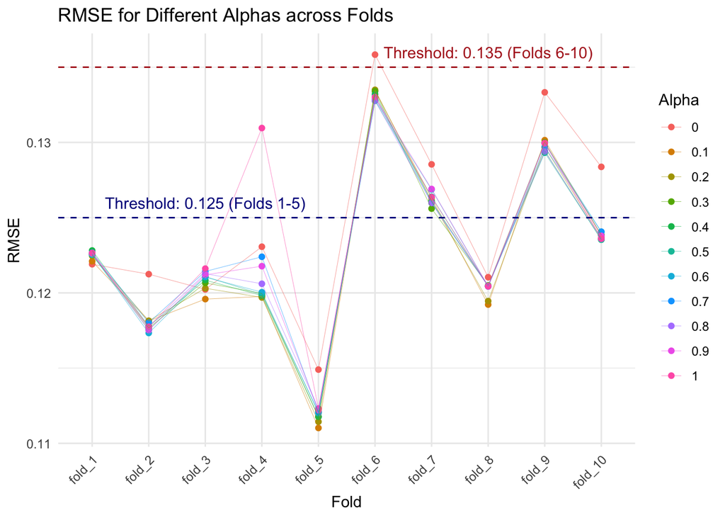

```r
# Line Plot with Thresholds
results_long$Fold <- factor(results_long$Fold, levels = paste0("fold_", 1:10))
ggplot(results_long, aes(x = Fold, y = RMSE, color = Alpha, group = Alpha)) +
  geom_point() +
  geom_line(linewidth = 0.1) +
  geom_hline(yintercept = 0.125, linetype = "dashed", color = "darkblue", size = 0.5) +
  geom_hline(yintercept = 0.135, linetype = "dashed", color = "firebrick", size = 0.5) +
  annotate("text", x = "fold_3", y = 0.126, label = "Threshold: 0.125 (Folds 1-5)", color = "darkblue") +
  annotate("text", x = "fold_8", y = 0.136, label = "Threshold: 0.135 (Folds 6-10)", color = "firebrick") +
  labs(title = "RMSE for Different Alphas across Folds",
       x = "Fold", y = "RMSE", color = "Alpha") +
  theme_minimal() +
  theme(axis.text.x = element_text(angle = 45, hjust = 1))
```

### 4.2. Random Forest

This section presents the Random Forest models predictions and results using 500 trees:

**Predictions**

```r
# RMSE of RandomForest model
RMSE.rf <- data.frame(matrix(ncol = 10, nrow = 1))
names(RMSE.rf) <- paste0("fold_", 1:10)

# Create a list to store predictions for each fold and alpha
predictions.rf <- list()

# Progress
pb <- progress_bar$new(total = 10, format = "[:bar] :percent :eta", clear = FALSE)

# Loop through the 10 folds for randomForest models
for (fold in 1:10) {

  # 0. Get X and Y for training the model
  x <- get(paste0("X.train_", fold))
  y <- get(paste0("Y.train_", fold))

  # 1. Train the random forest model
  rf_model <- randomForest(x, y, ntree = 500)

  # 2. Predict on test data
  test_ <- get(paste0("X.test_", fold))
  predictions_rf <- predict(rf_model, newdata = test_)

  # 3. Calculate RMSE
  test_y_ <- get(paste0("Y.test_", fold))
  RMSE.rf[1, paste0("fold_", fold)] <- sqrt(mean((predictions_rf - log(test_y_))^2))

  # Update the progress bar
  pb$tick()
}
```

**Results: RMSE**

```r
RMSE.rf
```

```
##      fold_1   fold_2    fold_3    fold_4   fold_5    fold_6    fold_7    fold_8
## 1 0.1338674 0.135268 0.1300334 0.1360245 0.124482 0.1462009 0.1480889 0.1433515
##      fold_9   fold_10
## 1 0.1494448 0.1362912
```

**Results: Plots**

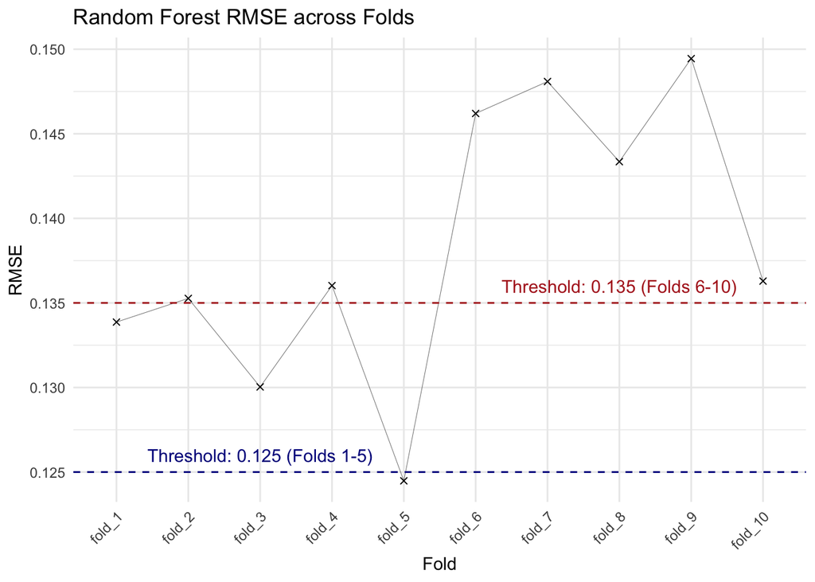

```r
# Convert RMSE.rf to long format
rf_results_long <- tidyr::pivot_longer(RMSE.rf, cols = starts_with("fold_"),
                                       names_to = "Fold", values_to = "RMSE")

# Line Plot with Thresholds for RandomForest
rf_results_long$Fold <- factor(rf_results_long$Fold, levels = paste0("fold_", 1:10))

ggplot(rf_results_long, aes(x = Fold, y = RMSE, group = 1)) +
  geom_point(shape=4) +
  geom_line(linewidth = 0.1) +
  geom_hline(yintercept = 0.125, linetype = "dashed", color = "darkblue", size = 0.5) +
  geom_hline(yintercept = 0.135, linetype = "dashed", color = "firebrick", size = 0.5) +
  annotate("text", x = "fold_3", y = 0.126, label = "Threshold: 0.125 (Folds 1-5)", color = "darkblue") +
  annotate("text", x = "fold_8", y = 0.136, label = "Threshold: 0.135 (Folds 6-10)", color = "firebrick") +
  labs(title = "Random Forest RMSE across Folds",
       x = "Fold", y = "RMSE") +
  theme_minimal() +
  theme(axis.text.x = element_text(angle = 45, hjust = 1))
```

This section presents the XGBoost models predictions and results:

**Predictions**

```r
# Placeholder for storing RMSE values for each fold
RMSE.xgb <- data.frame(matrix(ncol = 10, nrow = 1))
names(RMSE.xgb) <- paste0("fold_", 1:10)

# Create a list to store predictions for each fold
predictions.xgb <- list()

# Progress
pb <- progress_bar$new(total = 10, format = "[:bar] :percent :eta", clear = FALSE)

# Loop through the 10 folds for xgboost models
for (fold in 1:10) {

  # Prepare training and testing data in xgb.DMatrix format
  x_train <- get(paste0("X.train_", fold))
  y_train <- get(paste0("Y.train_", fold))
  dtrain <- xgb.DMatrix(data = as.matrix(x_train), label = y_train)

  x_test <- get(paste0("X.test_", fold))
  dtest <- xgb.DMatrix(data = as.matrix(x_test))

  # Train the XGBoost model
  xgb_model <- xgboost(data = dtrain, eta = 0.05, max_depth = 6, subsample = 0.5, nrounds = 5000, verbose=0)

  # Predict on test data
  predictions <- predict(xgb_model, dtest)

  # Compute RMSE
  test_y_ <- get(paste0("Y.test_", fold))
  RMSE.xgb[1, paste0("fold_", fold)] <- sqrt(mean((predictions - log(test_y_))^2))

  # Store the predictions (optional)
  predictions.xgb[[paste0("fold_", fold)]] <- predictions

  # Update the progress bar
  pb$tick()
}
```

**Results: RMSE**

```r
RMSE.xgb
```

```
##     fold_1    fold_2    fold_3    fold_4    fold_5   fold_6   fold_7   fold_8
## 1 0.113153 0.1196231 0.1117918 0.1179561 0.1102938 0.127407 0.133407 0.127257
##      fold_9   fold_10
## 1 0.1298802 0.1256042
```

**Results: Plots**

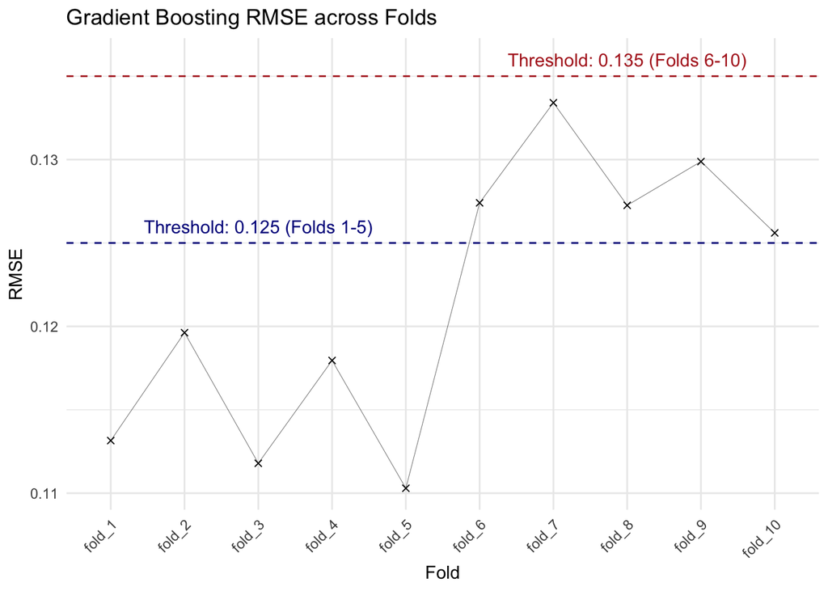

```r
# Convert RMSE.xgb to long format
rf_results_long <- tidyr::pivot_longer(RMSE.xgb, cols = starts_with("fold_"),
                                       names_to = "Fold", values_to = "RMSE")

# Line Plot with Thresholds for XGBoost
rf_results_long$Fold <- factor(rf_results_long$Fold, levels = paste0("fold_", 1:10))

ggplot(rf_results_long, aes(x = Fold, y = RMSE, group = 1)) +
  geom_point(shape=4) +
  geom_line(linewidth = 0.1) +
  geom_hline(yintercept = 0.125, linetype = "dashed", color = "darkblue", size = 0.5) +
  geom_hline(yintercept = 0.135, linetype = "dashed", color = "firebrick", size = 0.5) +
  annotate("text", x = "fold_3", y = 0.126, label = "Threshold: 0.125 (Folds 1-5)", color = "darkblue") +
  annotate("text", x = "fold_8", y = 0.136, label = "Threshold: 0.135 (Folds 6-10)", color = "firebrick") +
  labs(title = "Gradient Boosting RMSE across Folds",
       x = "Fold", y = "RMSE") +
  theme_minimal() +
  theme(axis.text.x = element_text(angle = 45, hjust = 1))
```